# 例一： 气候、环境对模型的的影响

主讲人：杨金炎  
2022-06-29

定义一个画图函数方便以后使用。

```r
plot.func <- function(out.1,out.2,
                      target.var = 'gpp',
                      y.name = 'GPP'){

  # 1
  plot(value~date,data = out.1[out.1$species == 'Fagus sylvatica' &
                                 out.1$variable == target.var,],
       type='l',xlab='',ylab=y.name,col='grey')

  points(value~date,data = out.1[out.1$species == 'Pinus sylvestris' &
                                   out.1$variable == target.var,],
         type='l',xlab='',col='red')

  legend('topleft',legend = unique(out.1$species),
         lty='solid',col=c('grey','red'),bty='n')
  # 2
  points(value~date,data = out.2[out.2$species ==
                                   'Fagus sylvatica' &
                                   out.2$variable == target.var,],
         type='l',xlab='',col='grey',lty='dashed')

  points(value~date,data = out.2[out.2$species ==
                                   'Pinus sylvestris' &
                                   out.2$variable == target.var,],
         type='l',xlab='',col='red',lty='dashed')
}
```

### 1. 如何改变初始参数

#### 1.1 初始土壤水分

首先，用原始数据运行模型。

```r
# 运行模型
output <- run_3PG(site = d_site,#站点相关信息，初始土壤水
                  species = d_species,#树种相关信息，初始生物量
                  climate = d_climate,#气象因子
                  thinning = d_thinning,#间苗
                  parameters = d_parameters,#按树种的生理参数
                  size_dist = d_sizeDist,#修正大小分布
                  settings = list(light_model = 1,
                                  transp_model = 2, phys_model = 2,
                                  correct_bias = 0, calculate_d13c = 0),
                  check_input = TRUE,
                  df_out = TRUE)
```

第二，我们改变初始土壤水含量。

```r
# 运行模型
site.new <- d_site
site.new$asw_i <- 1

output.sw <- run_3PG(site = site.new,#站点相关信息，初始土壤水
                  species = d_species,#树种相关信息，初始生物量
                  climate = d_climate,#气象因子
                  thinning = d_thinning,#间苗
                  parameters = d_parameters,#按树种的生理参数
                  size_dist = d_sizeDist,#修正大小分布
                  settings = list(light_model = 1,
                                  transp_model = 2, phys_model = 2,
                                  correct_bias = 0, calculate_d13c = 0),
                  check_input = TRUE,
                  df_out = TRUE)
```

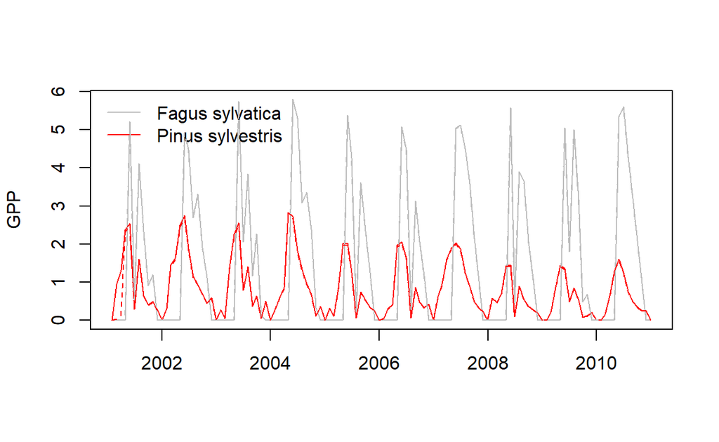

```r
# 作图
plot.func(out.1 = output,out.2 = output.sw)
```

初始土壤水改变巨大，但是模型的结果恢复很快。原因在于一月份降水很多蒸散失又少。水分不是胁迫因素。

```r
head(d_climate)
```

```
  year month    tmp_min   tmp_max   tmp_ave      prcp      srad
1 2001     1 -1.4669526  4.426295  1.255187 107.00000  8.406893
2 2001     2 -0.8616548  7.553571  2.982143  29.00000 12.664019
3 2001     3  3.8046124 11.463667  7.340946 195.79700 15.905757
4 2001     4  2.7947164 11.352311  6.585644 144.00001 17.775332
5 2001     5  9.7551870 20.884220 15.156178  57.20299 21.501787
6 2001     6 10.0666666 21.166666 15.428050 241.11404 18.191631
  frost_days     co2   d13catm
1         19 360.000 -7.677826
2         14 360.036 -7.677826
3         14 360.072 -7.677826
4          6 360.108 -7.677826
5          0 360.144 -7.677826
6          0 360.180 -7.677826
```

#### 1.2 初始生物量

我们假设Pinus sylvestris的叶生物量从3将为0.3。

```r
# 运行模型
spc.new <- d_species
spc.new$biom_foliage[spc.new$species ==  'Pinus sylvestris'] <- 0.3

output.spc <- run_3PG(site = d_site,#站点相关信息，初始土壤水
                  species = spc.new,#树种相关信息，初始生物量
                  climate = d_climate,#气象因子
                  thinning = d_thinning,#间苗
                  parameters = d_parameters,#按树种的生理参数
                  size_dist = d_sizeDist,#修正大小分布
                  settings = list(light_model = 1,
                                  transp_model = 2, phys_model = 2,
                                  correct_bias = 0, calculate_d13c = 0),
                  check_input = TRUE,
                  df_out = TRUE)
```

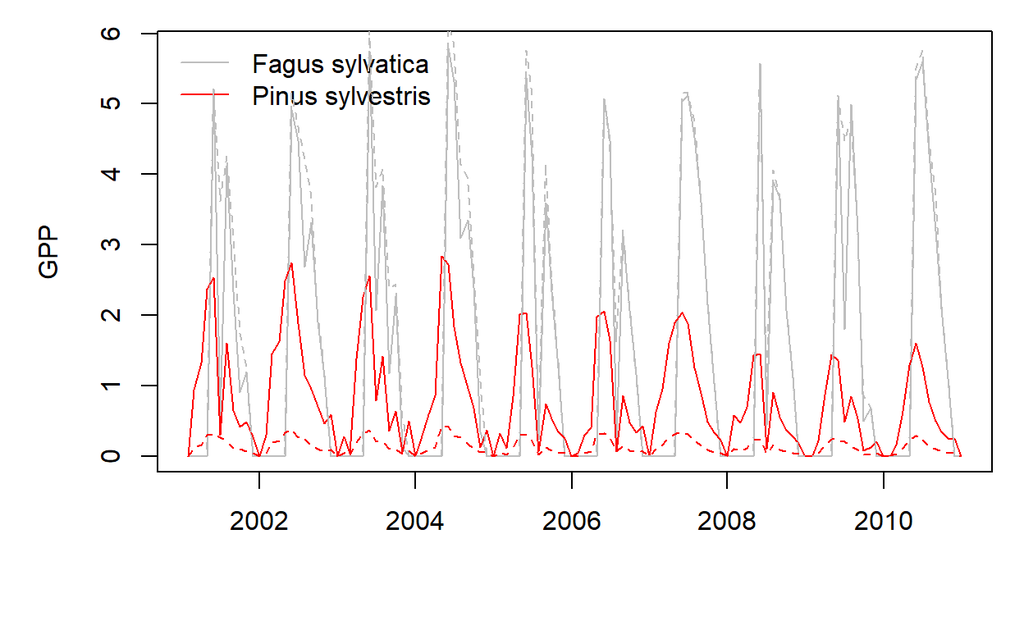

```r
# 作图
par(mar=c(5,5,1,1))
plot.func(out.1 = output,out.2 = output.spc)
```

可见初始叶生物量的影响是长期的。且一种植物的变化会影响其他植物。

### 2. 气候变化

基于上面类似的方法，我们可以预测气候变化对不同植物的影响。 例如，我们可以假设降水变为原先的一半。

```r
# 运行模型
met.new <- d_climate
met.new$prcp <- d_climate$prcp * 0.5

output.rain <- run_3PG(site = d_site,#站点相关信息，初始土壤水
                  species = d_species,#树种相关信息，初始生物量
                  climate = met.new,#气象因子
                  thinning = d_thinning,#间苗
                  parameters = d_parameters,#按树种的生理参数
                  size_dist = d_sizeDist,#修正大小分布
                  settings = list(light_model = 1,
                                  transp_model = 2, phys_model = 2,
                                  correct_bias = 0, calculate_d13c = 0),
                  check_input = TRUE,
                  df_out = TRUE)
```

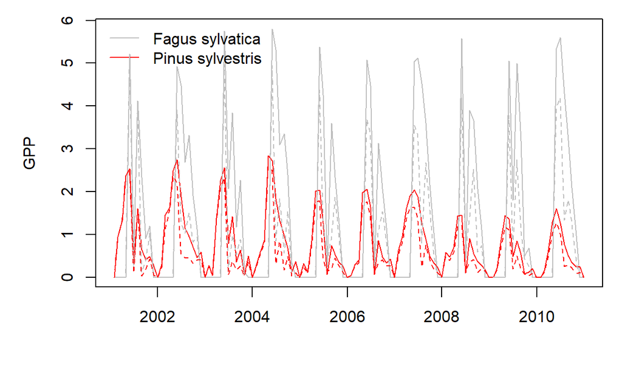

```r
# 作图
par(mar=c(5,5,1,1))
plot.func(out.1 = output,out.2 = output.rain)
```

可见降水对生产力影响巨大且不同植物的响应不同。

同样的我们也可以同时改变多种因素。这里我们模拟一种降水下降10%，温度上升4摄氏度，二氧化碳浓度上升60 p.p.m.的情况。

```r
# 运行模型
met.new <- d_climate
met.new$prcp <- d_climate$prcp * 0.9
met.new$tmp_min <- d_climate$tmp_min + 4
met.new$tmp_max <- d_climate$tmp_max + 4
met.new$tmp_ave <- d_climate$tmp_ave + 4
met.new$co2 <- d_climate$co2 + 60

output.met <- run_3PG(site = d_site,#站点相关信息，初始土壤水
                  species = d_species,#树种相关信息，初始生物量
                  climate = met.new,#气象因子
                  thinning = d_thinning,#间苗
                  parameters = d_parameters,#按树种的生理参数
                  size_dist = d_sizeDist,#修正大小分布
                  settings = list(light_model = 1,
                                  transp_model = 2, phys_model = 2,
                                  correct_bias = 0, calculate_d13c = 0),
                  check_input = TRUE,
                  df_out = TRUE)
```

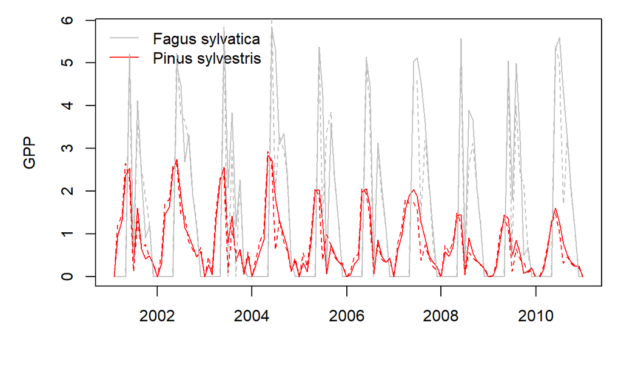

```r
# 作图
par(mar=c(5,5,1,1))
plot.func(out.1 = output,out.2 = output.met)
```

气候变化影响的不只有生产力，还有蒸腾作用。

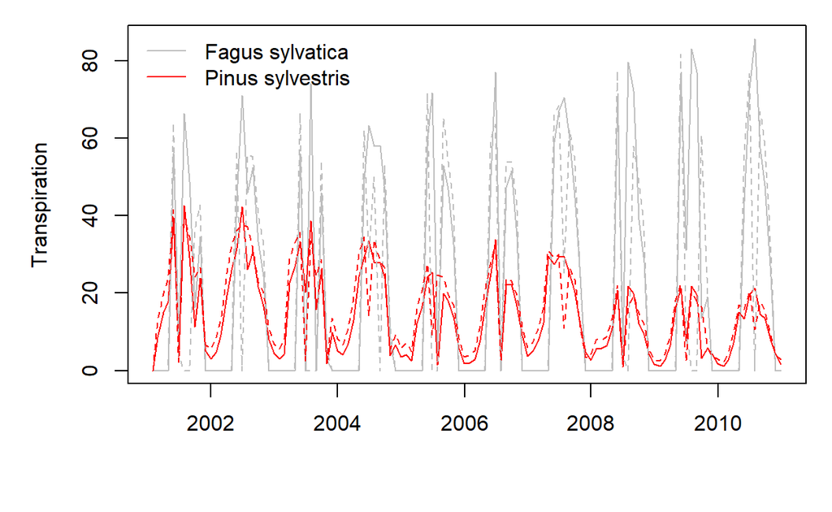

```r
# 作图
par(mar=c(5,5,1,1))
plot.func(out.1 = output,
          out.2 = output.met,
          target.var = 'transp_veg',
          y.name = 'Transpiration')
```

### 3. 如何获取气象数据

理想情况下，每一个站点都应该气象站记录的气象数据。但是，很多时候相应的数据不存在。那么，就需要查找缺失的数据或者找到其他气象数据来源。处理这两种问题的方法一致，都需要找到高质量的气候数据。

根据研究区域的不同，气象数据的来源可以很多。一般以邻近的气象站数据为佳。当没有实地测量的时候，就需要使用格网数据。下面提供两个可以实现全球覆盖的免费数据来源。

##### WorldClim

worldClimhttps://www.worldclim.org/ 较为常用。它可以提供过去和未来的气象数据。 下载后的worldclim可以使用R中的raster功能包中的raster函数直接读取。worldclim提供的是日尺度的气象数据，在下载后，还需要求和或取均值。此数据也可用其他常用语言处理。

##### Chelsa

Chelsahttps://chelsa-climate.org/ 是另外一种常用的数据来源。同样可以提供过去和未来的气象数据。起具体的内容和使用方法与worldclim类似。Chelsa的重要特点有：提供的数据种类更多（饱和蒸气压亏缺，潜在蒸散失）；在特定区域精度更好（喜马拉雅）。它的具体情况可以参考：

Karger, D.N., Wilson, A.M., Mahony, C., Zimmermann, N.E., Jetz, W. (2021): Global daily 1km land surface precipitation based on cloud cover-informed downscaling. Scientific Data. https://doi.org/10.1038/s41597-021-01084-6

Karger, D.N., Schmatz, D., Detttling, D., Zimmermann, N.E. (2020): High resolution monthly precipitation and temperature timeseries for the period 2006-2100. Scientific Data. https://doi.org/10.1038/s41597-020-00587-y